# Выживаемость и посещение форума

## 1. Об отчете

### Исследовательские вопросы

1. Как тип курса влияет на выживаемость студентов?
- **students** - длинная база данных, с данными на уровне студентов
- **courses** - короткая база данных, с данными на уровне курсов

### Описание переменных

- **Тип задания** - бинарные переменные; сообщают есть ли такой тип задания на курсе;
  - *is_prog* - есть ли задание по программированию;
  - *is_math* - есть ли задание по математике;
  - *is_peer* - есть ли пир-ревью.
- **Метрики форума**
  - *student_vis_mean* - среднее посещение форума студентами на курсе;
  - *ans_learner* - абсолютное количество ответов студентов на курсе;
  - *q_learner* - абсолютное количество вопросов студентов на курсе;
  - *ans_learner_n* - количество ответов студентов на курсе / количество студентов на курсе;
  - *q_learner_n* - количество вопросов студентов на курсе / количество студентов на курсе;
  - *forum_rate* - количество студентов заглянувших на форум / количество студентов на курсе.
- **Метрика выживаемости**
  - *passing_rate* - прошедшие курс / записавшиеся на курс и выполнившие хотя бы одно задание.

### Как создавались бинарные переменные типов заданий

- К сожалению, не всегда удается автоматически определить какие на курсе задания, а потому приходится использовать разнообразные признаки для их кодирования.
- *is_prog*
  - есть ли в таблице course_items.csv задания со словом “programming”;
  - есть ли в таблице assessment_questions.csv вопросы с типом 14 (codeExpression)
- *is_math*
  - есть ли задания в таблице assessment_math_expression_questions.csv;
  - есть ли в таблице peer_assignment_submission_schema_parts.csv слова “math”,“calculate”, “Рассчитайте”
- *is_peer*
  - есть ли в таблице ‘course_items.csv’ задание с типом 104 (peer-review);

## 2. Посещение форума и выживаемость на курсе

### 2.1 Анализ распределения остатков

Распределение переменных модели:

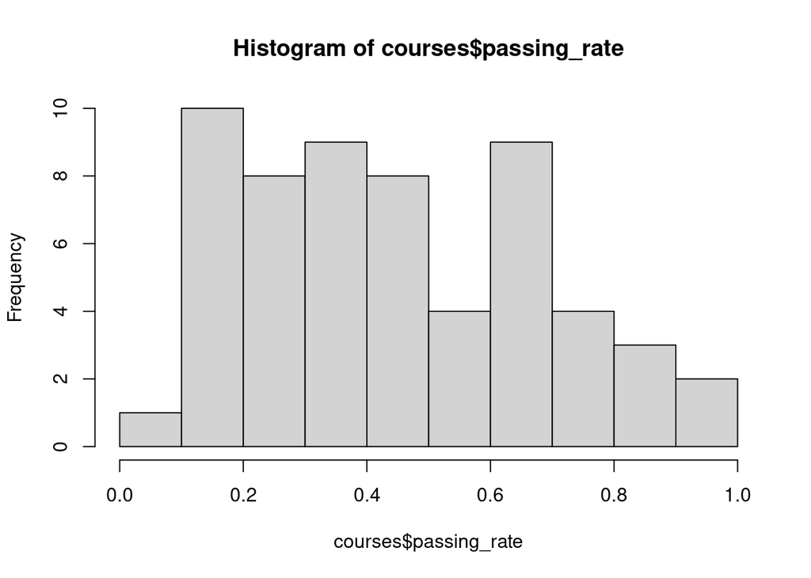

```r
hist(courses$passing_rate)
```

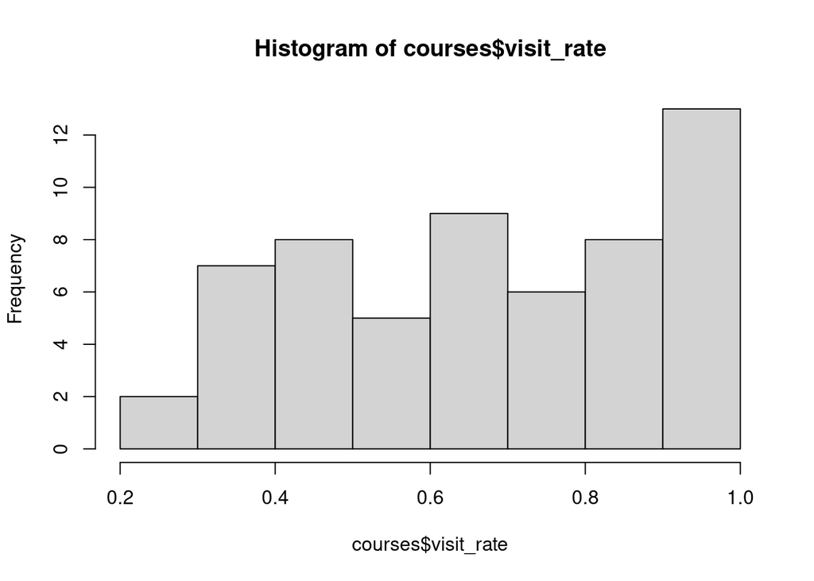

```r
hist(courses$visit_rate)
```

### 2.2 Выживаемость и среднее посещение форума

```r
m1 <-  lm(visit_rate ~ passing_rate, courses)
summary(m1)
```

```
##
## Call:
## lm(formula = visit_rate ~ passing_rate, data = courses)
##
## Residuals:
##      Min       1Q   Median       3Q      Max
## -0.36830 -0.15885  0.01579  0.13687  0.56092
##
## Coefficients:
##              Estimate Std. Error t value Pr(>|t|)
## (Intercept)   0.86914    0.05389  16.128  < 2e-16 ***
## passing_rate -0.43006    0.10638  -4.043 0.000163 ***
## ---
## Signif. codes:  0 '***' 0.001 '**' 0.01 '*' 0.05 '.' 0.1 ' ' 1
##
## Residual standard error: 0.1943 on 56 degrees of freedom
## Multiple R-squared:  0.2259, Adjusted R-squared:  0.2121
## F-statistic: 16.34 on 1 and 56 DF,  p-value: 0.0001629
```

Чтобы получить данное значение мы нашли разницу между интерсептом и интерсепт + угол наклона:

```
## Изменение на 1 пункт в выживаемости курса изменяет на -0.43 пунктов среднее количество посещений форума.
```

```
## Это изменение значимо с p = 0.000
```

Визуализация

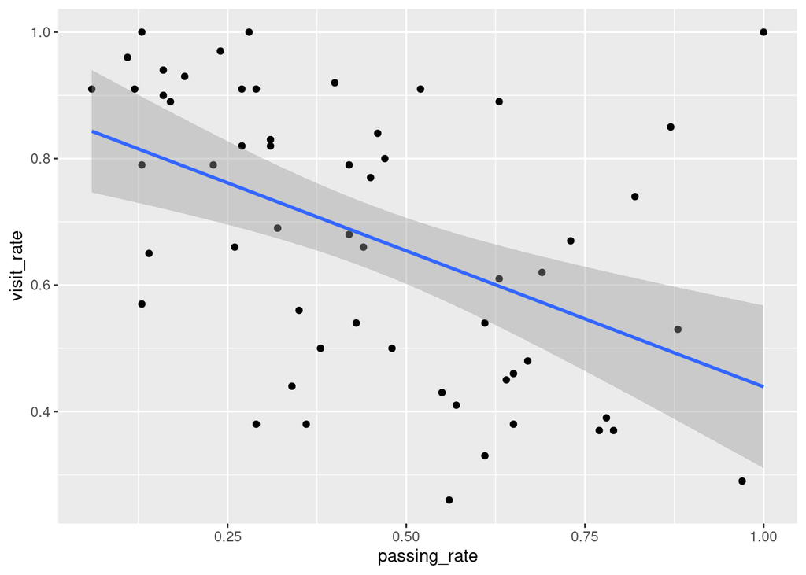

```r
courses %>%
  ggplot(aes(x = passing_rate, y = visit_rate)) + geom_point() +  geom_smooth(method = "lm")
```

Проверка нормальности распределения

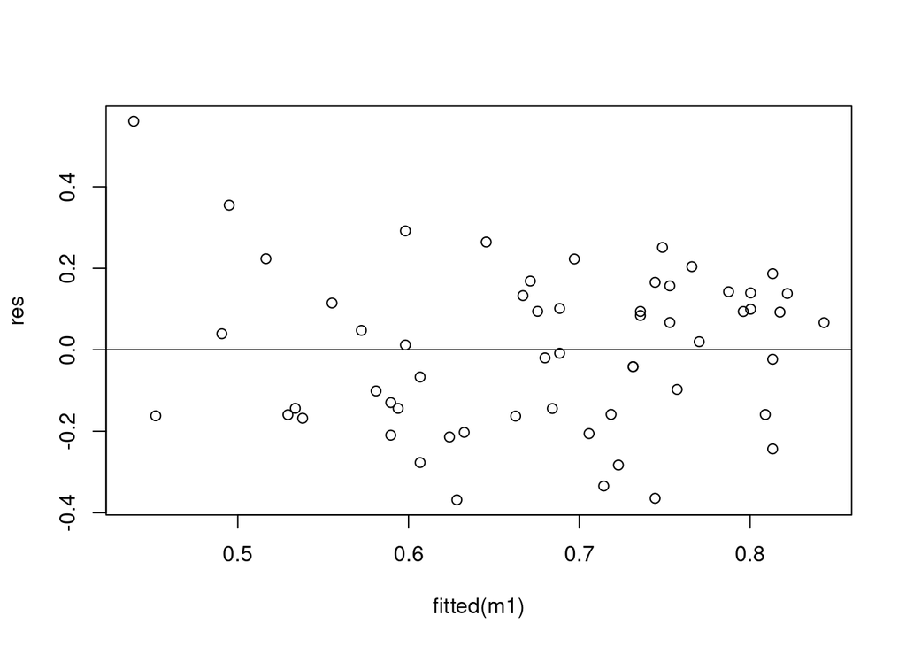

```r
m1 <-  lm(visit_rate ~ passing_rate, courses)
res <- resid(m1)
plot(fitted(m1), res)
abline(0,0)
```

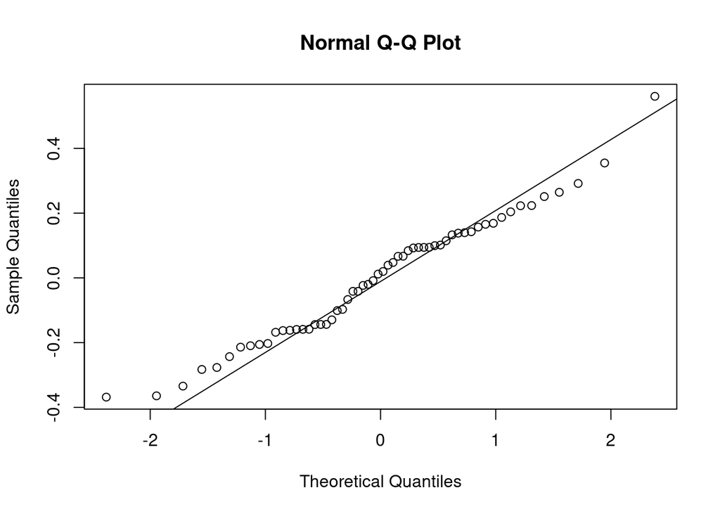

```r
qqnorm(res)
qqline(res)
```

## 3. Выживаемость и тип курса

```r
m1 <-  lm(passing_rate ~ is_prog_b, courses)
summary(m1)
```

```
##
## Call:
## lm(formula = passing_rate ~ is_prog_b, data = courses)
##
## Residuals:
##      Min       1Q   Median       3Q      Max
## -0.39822 -0.18572 -0.02822  0.17928  0.54178
##
## Coefficients:
##             Estimate Std. Error t value Pr(>|t|)
## (Intercept)  0.45822    0.03623   12.65   <2e-16 ***
## is_prog_b   -0.05361    0.07653   -0.70    0.487
## ---
## Signif. codes:  0 '***' 0.001 '**' 0.01 '*' 0.05 '.' 0.1 ' ' 1
##
## Residual standard error: 0.243 on 56 degrees of freedom
## Multiple R-squared:  0.008686,   Adjusted R-squared:  -0.009016
## F-statistic: 0.4907 on 1 and 56 DF,  p-value: 0.4865
```

```r
wt1 <- wilcox.test(passing_rate ~ is_prog_b, courses)
w1 <- courses %>% wilcox_effsize(passing_rate ~ is_prog_b)
wt1
```

```
##
##  Wilcoxon rank sum test with continuity correction
##
## data:  passing_rate by is_prog_b
## W = 332, p-value = 0.467
## alternative hypothesis: true location shift is not equal to 0
```

```r
w1
```

```
## # A tibble: 1 x 7
##   .y.          group1 group2 effsize    n1    n2 magnitude
## * <chr>        <chr>  <chr>    <dbl> <int> <int> <ord>
## 1 passing_rate 0      1       0.0967    45    13 small
```

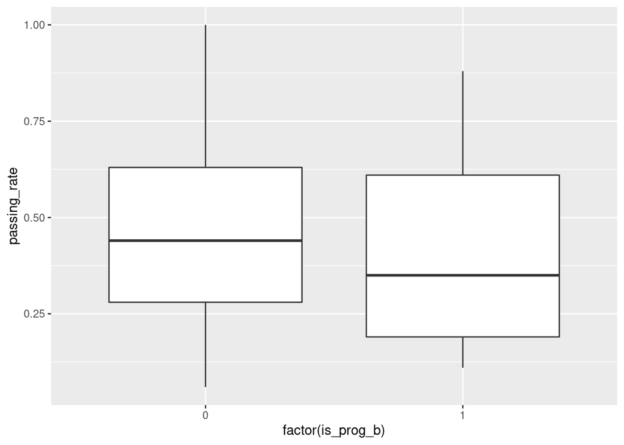

```r
courses %>%
  ggplot(aes(y = passing_rate, x = factor(is_prog_b))) + geom_boxplot()
```

## Выводы

[output not shown]